# lab06

Author

Carson Bainbridge

```r
library(tidyverse)
library(tidymodels)
library(powerjoin)
library(glue)
library(vip)
library(baguette)
```

```r
root  <- 'https://gdex.ucar.edu/dataset/camels/file'

download.file('https://gdex.ucar.edu/dataset/camels/file/camels_attributes_v2.0.pdf',
              'data/camels_attributes_v2.0.pdf')

types <- c("clim", "geol", "soil", "topo", "vege", "hydro")
# Where the files live online ...
remote_files  <- glue('{root}/camels_{types}.txt')
# where we want to download the data ...
local_files   <- glue('data/camels_{types}.txt')

walk2(remote_files, local_files, download.file, quiet = TRUE)

# Read and merge data
camels <- map(local_files, read_delim, show_col_types = FALSE)

camels <- power_full_join(camels ,by = 'gauge_id')

# Read and merge data
camels <- map(remote_files, read_delim, show_col_types = FALSE) |>
  power_full_join(by = 'gauge_id')
```

Question One -zero_q_freq means frequency of days with Q = 0 mm/day, measured by percentage.

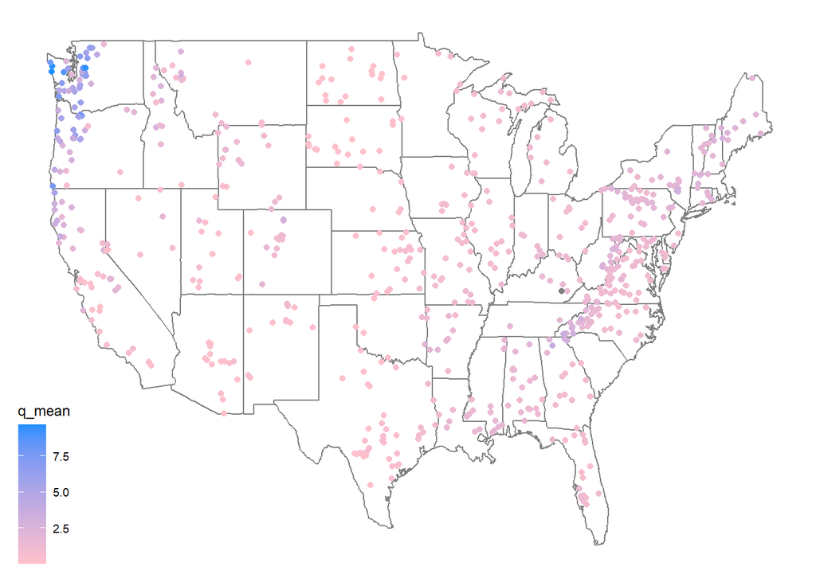

```r
ggplot(data = camels, aes(x = gauge_lon, y = gauge_lat)) +
  borders("state", colour = "gray50") +
  geom_point(aes(color = q_mean)) +
  scale_color_gradient(low = "pink", high = "dodgerblue") +
  ggthemes::theme_map()
```

Question 2: 1.Make 2 maps of the sites, coloring the points by the aridty and p_mean column 2.Add clear labels, titles, and a color scale that makes sense for each parameter. 3.Ensure these render as a single image with your choice of facet_*, patchwork, or ggpubr

```r
camels |>
  select(aridity, p_mean, q_mean) |>
  drop_na() |>
  cor()
```

```
           aridity     p_mean     q_mean
aridity  1.0000000 -0.7550090 -0.5817771
p_mean  -0.7550090  1.0000000  0.8865757
q_mean  -0.5817771  0.8865757  1.0000000
```

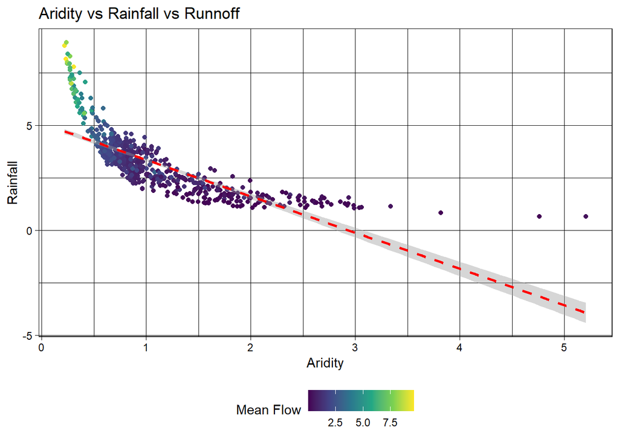

```r
# Create a scatter plot of aridity vs rainfall
ggplot(camels, aes(x = aridity, y = p_mean)) +
  # Add points colored by mean flow
  geom_point(aes(color = q_mean)) +
  # Add a linear regression line
  geom_smooth(method = "lm", color = "red", linetype = 2) +
  # Apply the viridis color scale
  scale_color_viridis_c() +
  # Add a title, axis labels, and theme (w/ legend on the bottom)
  theme_linedraw() +
  theme(legend.position = "bottom") +
  labs(title = "Aridity vs Rainfall vs Runnoff",
       x = "Aridity",
       y = "Rainfall",
       color = "Mean Flow")
```

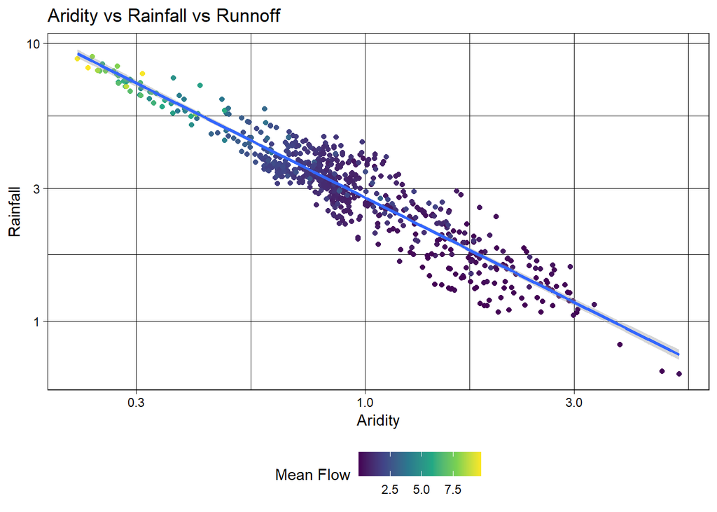

```r
ggplot(camels, aes(x = aridity, y = p_mean)) +
  geom_point(aes(color = q_mean)) +
  geom_smooth(method = "lm") +
  scale_color_viridis_c() +
  # Apply log transformations to the x and y axes
  scale_x_log10() +
  scale_y_log10() +
  theme_linedraw() +
  theme(legend.position = "bottom") +
  labs(title = "Aridity vs Rainfall vs Runnoff",
       x = "Aridity",
       y = "Rainfall",
       color = "Mean Flow")
```

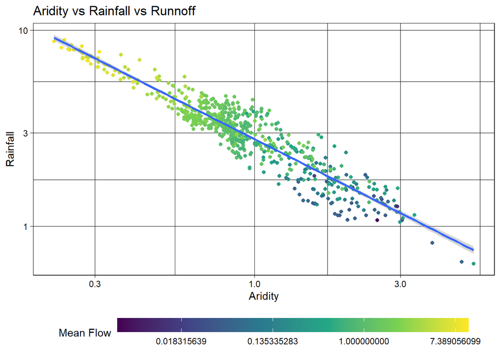

```r
ggplot(camels, aes(x = aridity, y = p_mean)) +
  geom_point(aes(color = q_mean)) +
  geom_smooth(method = "lm") +
  # Apply a log transformation to the color scale
  scale_color_viridis_c(trans = "log") +
  scale_x_log10() +
  scale_y_log10() +
  theme_linedraw() +
  theme(legend.position = "bottom",
        # Expand the legend width ...
        legend.key.width = unit(2.5, "cm"),
        legend.key.height = unit(.5, "cm")) +
  labs(title = "Aridity vs Rainfall vs Runnoff",
       x = "Aridity",
       y = "Rainfall",
       color = "Mean Flow")
```

```r
set.seed(123)
# Bad form to perform simple transformations on the outcome variable within a
# recipe. So, we'll do it here.
camels <- camels |>
  mutate(logQmean = log(q_mean))

# Generate the split
camels_split <- initial_split(camels, prop = 0.8)
camels_train <- training(camels_split)
camels_test  <- testing(camels_split)

camels_cv <- vfold_cv(camels_train, v = 10)


# Create a recipe to preprocess the data
rec <-  recipe(logQmean ~ aridity + p_mean, data = camels_train) %>%
  # Log transform the predictor variables (aridity and p_mean)
  step_log(all_predictors()) %>%
  # Add an interaction term between aridity and p_mean
  step_interact(terms = ~ aridity:p_mean) |>
  # Drop any rows with missing values in the pred
  step_naomit(all_predictors(), all_outcomes())
```

```r
# Prepare the data
baked_data <- prep(rec, camels_train) |>
  bake(new_data = NULL)

# Interaction with lm
#  Base lm sets interaction terms with the * symbol
lm_base <- lm(logQmean ~ aridity * p_mean, data = baked_data)
summary(lm_base)
```

```
Call:
lm(formula = logQmean ~ aridity * p_mean, data = baked_data)

Residuals:
     Min       1Q   Median       3Q      Max
-2.91162 -0.21601 -0.00716  0.21230  2.85706

Coefficients:
               Estimate Std. Error t value Pr(>|t|)
(Intercept)    -1.77586    0.16365 -10.852  < 2e-16 ***
aridity        -0.88397    0.16145  -5.475 6.75e-08 ***
p_mean          1.48438    0.15511   9.570  < 2e-16 ***
aridity:p_mean  0.10484    0.07198   1.457    0.146
---
Signif. codes:  0 '***' 0.001 '**' 0.01 '*' 0.05 '.' 0.1 ' ' 1

Residual standard error: 0.5696 on 531 degrees of freedom
Multiple R-squared:  0.7697,    Adjusted R-squared:  0.7684
F-statistic: 591.6 on 3 and 531 DF,  p-value: < 2.2e-16
```

```r
# Sanity Interaction term from recipe ... these should be equal!!
summary(lm(logQmean ~ aridity + p_mean + aridity_x_p_mean, data = baked_data))
```

```
Call:
lm(formula = logQmean ~ aridity + p_mean + aridity_x_p_mean,
    data = baked_data)

Residuals:
     Min       1Q   Median       3Q      Max
-2.91162 -0.21601 -0.00716  0.21230  2.85706

Coefficients:
                 Estimate Std. Error t value Pr(>|t|)
(Intercept)      -1.77586    0.16365 -10.852  < 2e-16 ***
aridity          -0.88397    0.16145  -5.475 6.75e-08 ***
p_mean            1.48438    0.15511   9.570  < 2e-16 ***
aridity_x_p_mean  0.10484    0.07198   1.457    0.146
---
Signif. codes:  0 '***' 0.001 '**' 0.01 '*' 0.05 '.' 0.1 ' ' 1

Residual standard error: 0.5696 on 531 degrees of freedom
Multiple R-squared:  0.7697,    Adjusted R-squared:  0.7684
F-statistic: 591.6 on 3 and 531 DF,  p-value: < 2.2e-16
```

```r
test_data <-  bake(prep(rec), new_data = camels_test)
test_data$lm_pred <- predict(lm_base, newdata = test_data)

metrics(test_data, truth = logQmean, estimate = lm_pred)
```

```
# A tibble: 3 × 3
  .metric .estimator .estimate
  <chr>   <chr>          <dbl>
1 rmse    standard       0.583
2 rsq     standard       0.742
3 mae     standard       0.390
```

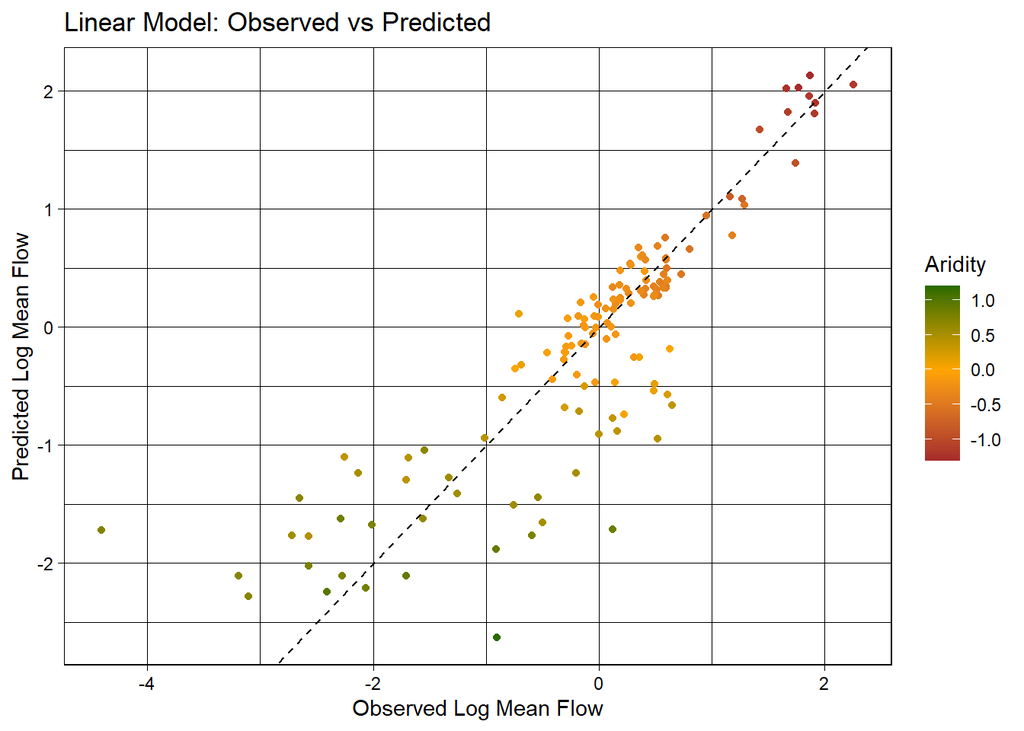

```r
ggplot(test_data, aes(x = logQmean, y = lm_pred, colour = aridity)) +
  # Apply a gradient color scale
  scale_color_gradient2(low = "brown", mid = "orange", high = "darkgreen") +
  geom_point() +
  geom_abline(linetype = 2) +
  theme_linedraw() +
  labs(title = "Linear Model: Observed vs Predicted",
       x = "Observed Log Mean Flow",
       y = "Predicted Log Mean Flow",
       color = "Aridity")
```

Using workflow instead

```r
# Define model
lm_model <- linear_reg() %>%
  # define the engine
  set_engine("lm") %>%
  # define the mode
  set_mode("regression")

# Instantiate a workflow ...
lm_wf <- workflow() %>%
  # Add the recipe
  add_recipe(rec) %>%
  # Add the model
  add_model(lm_model) %>%
  # Fit the model to the training data
  fit(data = camels_train)

# Extract the model coefficients from the workflow
summary(extract_fit_engine(lm_wf))$coefficients
```

```
                   Estimate Std. Error    t value     Pr(>|t|)
(Intercept)      -1.7758557 0.16364755 -10.851710 6.463654e-25
aridity          -0.8839738 0.16144589  -5.475357 6.745512e-08
p_mean            1.4843771 0.15511117   9.569762 4.022500e-20
aridity_x_p_mean  0.1048449 0.07198145   1.456555 1.458304e-01
```

```r
# From the base implementation
summary(lm_base)$coefficients
```

```
                 Estimate Std. Error    t value     Pr(>|t|)
(Intercept)    -1.7758557 0.16364755 -10.851710 6.463654e-25
aridity        -0.8839738 0.16144589  -5.475357 6.745512e-08
p_mean          1.4843771 0.15511117   9.569762 4.022500e-20
aridity:p_mean  0.1048449 0.07198145   1.456555 1.458304e-01
```

```r
#
lm_data <- augment(lm_wf, new_data = camels_test)
dim(lm_data)
```

[output not shown]

```r
metrics(lm_data, truth = logQmean, estimate = .pred)
```

```
# A tibble: 3 × 3
  .metric .estimator .estimate
  <chr>   <chr>          <dbl>
1 rmse    standard       0.583
2 rsq     standard       0.742
3 mae     standard       0.390
```

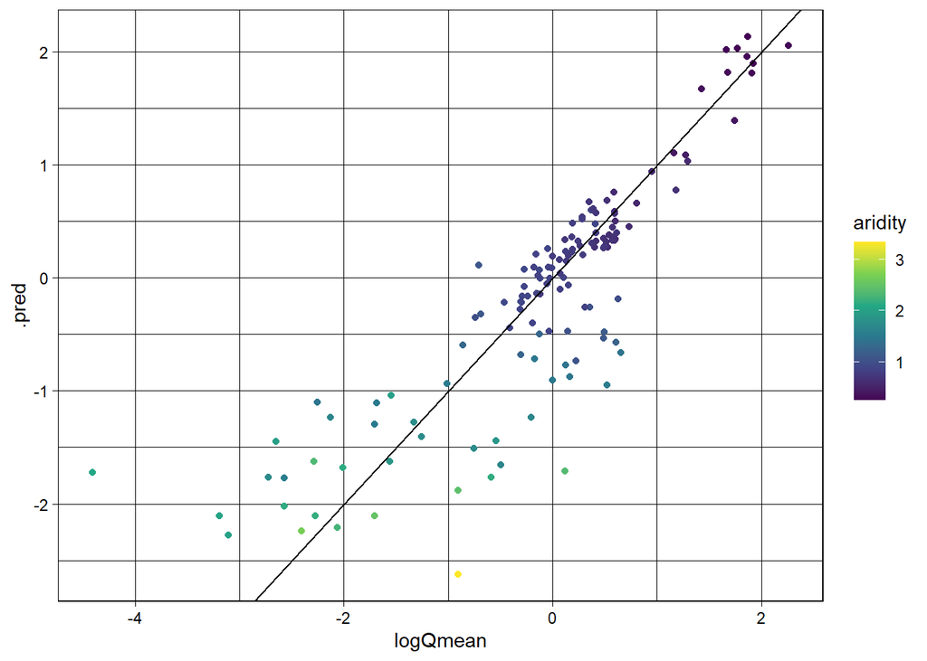

```r
ggplot(lm_data, aes(x = logQmean, y = .pred, colour = aridity)) +
  scale_color_viridis_c() +
  geom_point() +
  geom_abline() +
  theme_linedraw()
```

```r
library(baguette)
rf_model <- rand_forest() %>%
  set_engine("ranger", importance = "impurity") %>%
  set_mode("regression")

rf_wf <- workflow() %>%
  # Add the recipe
  add_recipe(rec) %>%
  # Add the model
  add_model(rf_model) %>%
  # Fit the model
  fit(data = camels_train)
```

```r
rf_data <- augment(rf_wf, new_data = camels_test)
dim(rf_data)
```

```
[1] 135  60
```

```r
metrics(rf_data, truth = logQmean, estimate = .pred)
```

```
# A tibble: 3 × 3
  .metric .estimator .estimate
  <chr>   <chr>          <dbl>
1 rmse    standard       0.588
2 rsq     standard       0.740
3 mae     standard       0.365
```

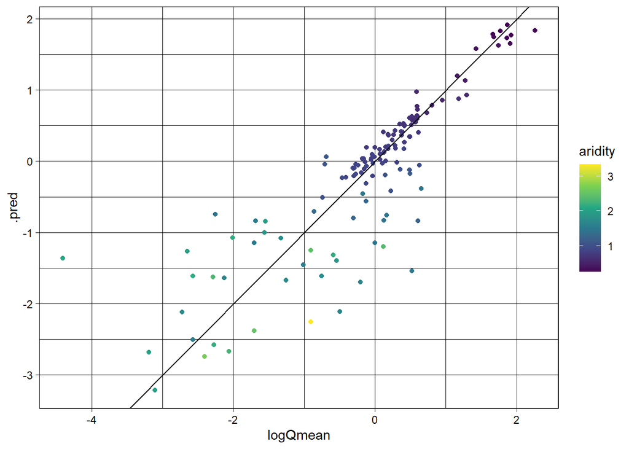

```r
ggplot(rf_data, aes(x = logQmean, y = .pred, colour = aridity)) +
  scale_color_viridis_c() +
  geom_point() +
  geom_abline() +
  theme_linedraw()
```

Workflow approach

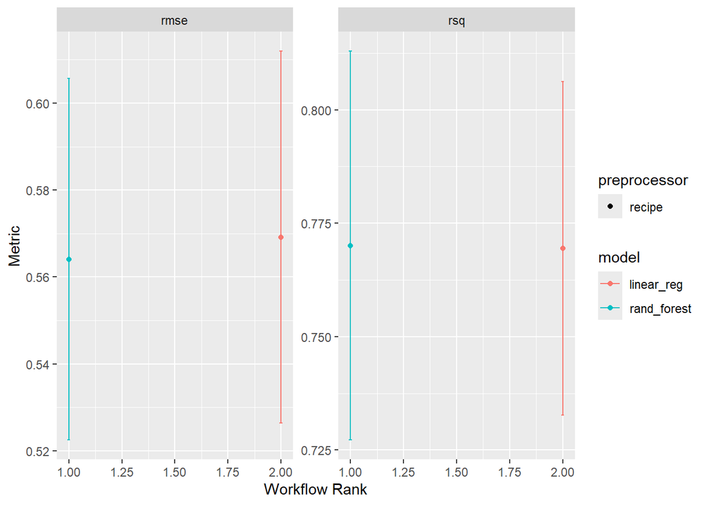

```r
wf <- workflow_set(list(rec), list(lm_model, rf_model)) %>%
  workflow_map('fit_resamples', resamples = camels_cv)
autoplot(wf)
```

```r
rank_results(wf, rank_metric = "rsq", select_best = TRUE)
```

```
# A tibble: 4 × 9
  wflow_id          .config .metric  mean std_err     n preprocessor model  rank
  <chr>             <chr>   <chr>   <dbl>   <dbl> <int> <chr>        <chr> <int>
1 recipe_rand_fore… Prepro… rmse    0.564  0.0253    10 recipe       rand…     1
2 recipe_rand_fore… Prepro… rsq     0.770  0.0260    10 recipe       rand…     1
3 recipe_linear_reg Prepro… rmse    0.569  0.0260    10 recipe       line…     2
4 recipe_linear_reg Prepro… rsq     0.770  0.0223    10 recipe       line…     2
```

ANSWERS FOR QUESTION TWO

```r
library(ggplot2)
library(patchwork)
library(ggthemes)
```

```r
map1 <- ggplot(data = camels, aes(x = gauge_lon, y = gauge_lat)) +
  borders("state", colour = "gray50") +
  geom_point(aes(color = p_mean)) +
  scale_color_gradient(low = "pink", high = "dodgerblue") +
  ggthemes::theme_map()+
  labs(title = "Camel Gauge Locations based on p_mean",
       x = "Longitude",
       y = "Latitude",
       color = "Aridity Index")
```

```r
map2 <- ggplot(data = camels, aes(x = gauge_lon, y = gauge_lat)) +
  borders("state", colour = "gray50") +
  geom_point(aes(color = aridity)) +
  scale_color_gradient(low = "pink", high = "dodgerblue") +
  ggthemes::theme_map()+
  labs(title = "Camel Gauge Locations based on aridity",
       x = "Longitude",
       y = "Latitude",
       color = "Aridity Index")
```

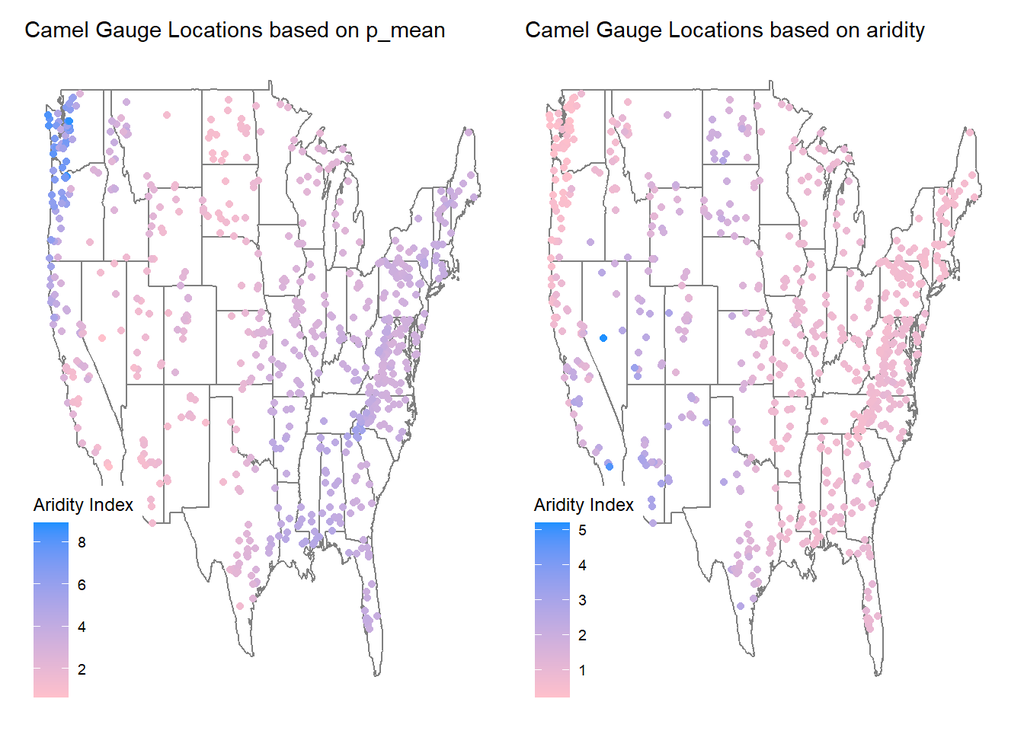

```r
combined <- map1 + map2
print(combined)
```

Question Three: 1. Build a xgboost (engine) regression (mode) model using boost_tree 2.Build a neural network model using the nnet engine from the baguette package using the bag_mlp function 3.Add this to the above workflow 4.Evaluate the model and compare it to the linear and random forest models 5.Which of the 4 models would you move forward with?

XGB model

```r
library(tidymodels)
library(baguette)
library(nnet)
library(dplyr)
library(parsnip)

split_data <- initial_split(camels, prop = 0.8)
train_data <- training(split_data)
test_data <- testing(split_data)

camel_recipe <- recipe(aridity ~ ., data = train_data) %>%
  step_normalize(all_numeric_predictors())

xgb_model <- boost_tree(
  mode = "regression",
  engine = "xgboost",
  trees = 500,
  tree_depth = 6,
  learn_rate = 0.05
)

folds <- vfold_cv(camels, v = 10)
```

Neural Network

```r
library(nnet)
library(baguette)
library(tidymodels)


split_data <- initial_split(camels, prop = 0.8)
train_data <- training(split_data)
test_data <- testing(split_data)

rec <- recipe(q_mean ~ aridity, precipitation, data = train_data) %>%
  step_normalize(all_numeric_predictors())

nn_model <- bag_mlp(
  hidden = 10,
  engine = "nnet",
  mode = "regression"
)

nn_mod_wf <- workflow() %>%
  add_recipe(rec) %>%
  add_model(nn_model) %>%
  fit(data = train_data)
```

```r
wf <- workflow_set(list(rec), list(nn_model, xgb_model, rf_model, lm_model)) %>%
  workflow_map('fit_resamples', resamples = camels_cv)
```

[output not shown]

```
There were issues with some computations   A: x1
```

```
→ B | error:   [22:11:08] src/data/data.cc:461: Check failed: valid: Label contains NaN, infinity or a value too large.
```

[output not shown]

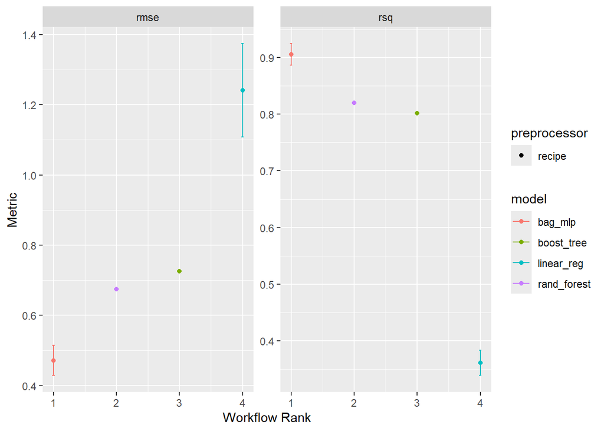

```r
autoplot(wf)
```

Data Splitting

```r
library(dplyr)
library(tidyverse)

df <- camels %>%
  mutate(logQmean = log(q_mean)) %>%
  select(logQmean, p_mean, aridity, soil_depth_pelletier, max_water_content, organic_frac, frac_snow, pet_mean, soil_depth_statsgo, elev_mean) %>%
  na.omit()

set.seed(1991)
camels <- drop_na(camels)

csplit_data <- initial_split(df, prop = 0.8)
ctrain_data <- training(csplit_data)
ctest_data <- testing(csplit_data)

camels_cv <- vfold_cv(ctrain_data, v = 10)
```

Recipe

```r
#formula
logQmean ~ runoff_ratio + zero_q_freq + runoff_ratio:zero_q_freq
```

```
logQmean ~ runoff_ratio + zero_q_freq + runoff_ratio:zero_q_freq
```

```r
#recipe
rec <- recipe("logQmean" ~ ., data = ctrain_data) %>%
  step_scale(all_predictors()) %>%
  step_center(all_predictos())%>%
  step_dummy(all_factor_predictors())
```

Define 3 Models

```r
#Random Forest Model
rf <- rand_forest (mode = "regression") %>%
  set_engine("ranger")

#decision tree model
dt <- decision_tree() %>%
  set_engine("rpart") %>%
  set_mode("classification")

#XGBoost model
xgb <- boost_tree( mode = "regression", trees = 500)

list(camels)
```

```
[[1]]
# A tibble: 507 × 59
   gauge_id p_mean pet_mean p_seasonality frac_snow aridity high_prec_freq
   <chr>     <dbl>    <dbl>         <dbl>     <dbl>   <dbl>          <dbl>
 1 01022500   3.61     2.12       -0.115      0.245   0.587           20.6
 2 01031500   3.52     2.07        0.104      0.292   0.588           18.9
 3 01047000   3.32     2.09        0.148      0.280   0.629           20.1
 4 01052500   3.73     2.10        0.152      0.353   0.562           13.5
 5 01054200   4.07     2.13        0.105      0.300   0.523           17.5
 6 01055000   3.49     2.09        0.167      0.306   0.599           19.2
 7 01057000   3.57     2.13        0.0791     0.251   0.597           20.4
 8 01073000   3.50     2.21        0.0304     0.175   0.630           20.8
 9 01078000   3.56     2.18        0.110      0.240   0.613           21.4
10 01118300   3.90     2.31       -0.0377     0.111   0.593           21.5
# ℹ 497 more rows
# ℹ 52 more variables: high_prec_dur <dbl>, high_prec_timing <chr>,
#   low_prec_freq <dbl>, low_prec_dur <dbl>, low_prec_timing <chr>,
#   geol_1st_class <chr>, glim_1st_class_frac <dbl>, geol_2nd_class <chr>,
#   glim_2nd_class_frac <dbl>, carbonate_rocks_frac <dbl>, geol_porostiy <dbl>,
#   geol_permeability <dbl>, soil_depth_pelletier <dbl>,
#   soil_depth_statsgo <dbl>, soil_porosity <dbl>, soil_conductivity <dbl>, …
```

Workflow Set

```r
set.seed(1991)
camels <- drop_na(camels)

csplit_data <- initial_split(df, prop = 0.8)
ctrain_data <- training(csplit_data)
ctest_data <- testing(csplit_data)


rec <- recipe(p_mean ~ aridity, precipitation, data = train_data) %>%
  step_scale(all_numeric_predictors()) %>%
  step_normalize(all_numeric_predictors())

camels_cv <- vfold_cv(ctrain_data, v = 10)

#models
xgb <- boost_tree( mode = "regression", trees = 500)
rf <- rand_forest (mode = "regression") %>%
  set_engine("ranger")


xgb_wf <- workflow() %>%
  add_recipe(rec) %>%
  add_model(xgb) %>%
  fit(data = ctrain_data)

rf_mod_wf <- workflow() %>%
  add_recipe(rec) %>%
  add_model(rf) %>%
  fit(data = ctrain_data)

dt <- decision_tree(mode = "regression") %>%
  set_engine("rpart")

dt_wf <- workflow() %>%
  add_recipe(rec) %>%
  add_model(dt) %>%
  fit(data = ctrain_data)
```

Extact and Evaluate

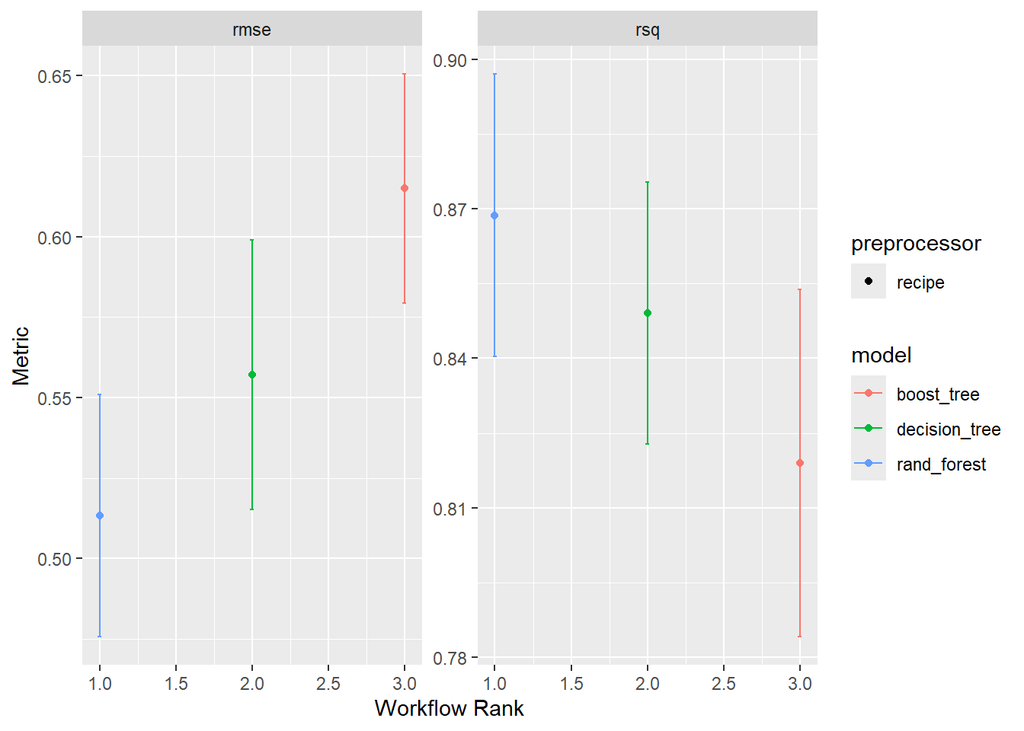

```r
wf_camel <- workflow_set(list(rec), list(xgb, dt, rf)) %>%
  workflow_map('fit_resamples', resamples = camels_cv)

autoplot(wf_camel)
```

```r
library(parsnip)

rf_wf <- workflow() %>%
  add_recipe(rec) %>%
  add_model(rf) %>%
  fit(data = ctrain_data)

#Making Predictions

rf_data <- augment(rf_wf, new_data = ctest_data)
dim(rf_data)
```

```
[1] 134  11
```

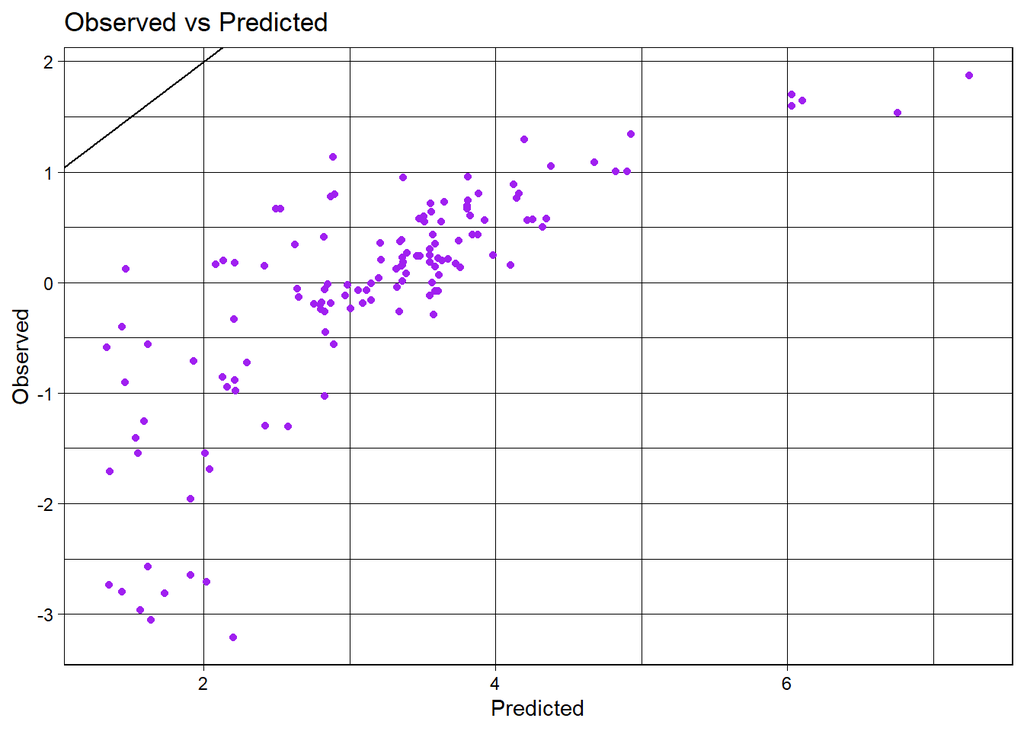

```r
ggplot(rf_data, aes(x = .pred, y = logQmean)) +
  geom_point(color = "purple") +
  geom_abline() +
  theme_linedraw() +
  labs(title = "Observed vs Predicted",
       x = "Predicted",
       y = "Observed")
```

```r
list(ctest_data)
```

```
[[1]]
# A tibble: 134 × 10
   logQmean p_mean aridity soil_depth_pelletier max_water_content organic_frac
      <dbl>  <dbl>   <dbl>                <dbl>             <dbl>        <dbl>
 1    1.00    4.07   0.523                0.915             0.595            0
 2    0.563   3.56   0.613                3.64              0.619            0
 3    0.552   3.82   0.603                9.09              0.534            0
 4    0.594   3.30   0.644                2.51              0.518            0
 5    0.608   3.78   0.597                9.32              0.604            0
 6    0.805   3.92   0.574                3.96              0.513            0
 7    0.766   3.82   0.594                5.03              0.484            0
 8    0.694   3.95   0.577                6.96              0.507            0
 9    0.746   3.87   0.580                1.92              0.454            0
10    0.806   3.98   0.560                1.06              0.298            0
# ℹ 124 more rows
# ℹ 4 more variables: frac_snow <dbl>, pet_mean <dbl>,
#   soil_depth_statsgo <dbl>, elev_mean <dbl>
```

I made a better looking graph (more linear) with q_mean that I would have rather submitted (I could sumbit a photo later if theres any concern with this graph) but for some reason it was the only error preventing me from rendering this html, so my apologies